# Report for A Giles

Aidan O’Hara

2023-03-31

# EXOMES and REA Model Report

## Study Aims

- To compare the report outcomes on initial exome reports between REA groups
- To compare reclassification rates and outcomes between REA groups
- To compare reclassification evidence types used between REA groups

## Proportional Analysis and EDA

Proportion between REA and classification, original reports

```r
propTableOg
```

```
## # A tibble: 8 × 4
## # Groups:   abcBuckets [8]
##   abcBuckets  `-1`   `0`   `1`
##   <fct>      <dbl> <dbl> <dbl>
## 1 A          0.645 0.155 0.200
## 2 AB         0.600 0.172 0.228
## 3 ABC        0.631 0.155 0.215
## 4 AC         0.649 0.154 0.197
## 5 B          0.595 0.169 0.235
## 6 BC         0.653 0.188 0.160
## 7 C          0.545 0.207 0.248
## 8 N/A        0.651 0.158 0.190
```

```r
propTableOg2
```

```
## # A tibble: 8 × 4
## # Groups:   abcBuckets [8]
##   abcBuckets  `-1`   `0`   `1`
##   <fct>      <int> <int> <int>
## 1 A           3464   835  1072
## 2 AB           377   108   143
## 3 ABC          147    36    50
## 4 AC           194    46    59
## 5 B           2083   592   824
## 6 BC            94    27    23
## 7 C            132    50    60
## 8 N/A          329    80    96
```

Proportion between REA and classification, latest reports

```r
propTable
```

```
## # A tibble: 8 × 4
## # Groups:   abcBuckets [8]
##   abcBuckets  `-1`   `0`   `1`
##   <fct>      <dbl> <dbl> <dbl>
## 1 A          0.617 0.151 0.232
## 2 AB         0.568 0.164 0.268
## 3 ABC        0.597 0.163 0.240
## 4 AC         0.629 0.147 0.224
## 5 B          0.569 0.171 0.260
## 6 BC         0.632 0.188 0.181
## 7 C          0.508 0.194 0.298
## 8 N/A        0.630 0.162 0.208
```

```r
propTable2
```

```
## # A tibble: 8 × 4
## # Groups:   abcBuckets [8]
##   abcBuckets  `-1`   `0`   `1`
##   <fct>      <int> <int> <int>
## 1 A           3315   812  1244
## 2 AB           357   103   168
## 3 ABC          139    38    56
## 4 AC           188    44    67
## 5 B           1991   598   910
## 6 BC            91    27    26
## 7 C            123    47    72
## 8 N/A          318    82   105
```

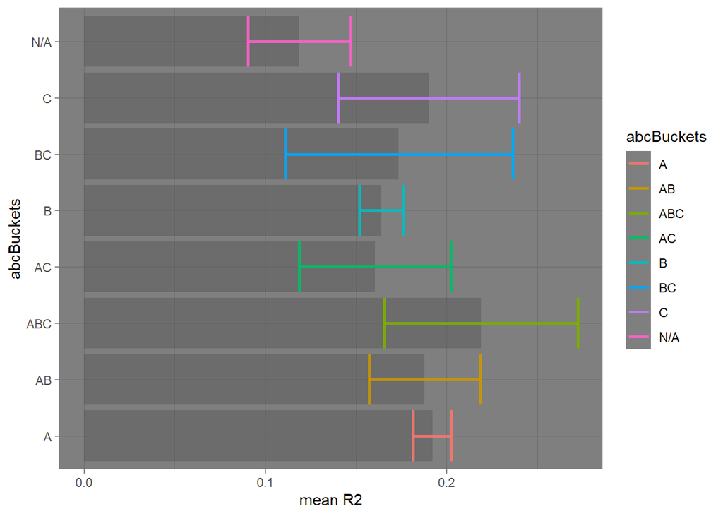

```r
reanazGG
```

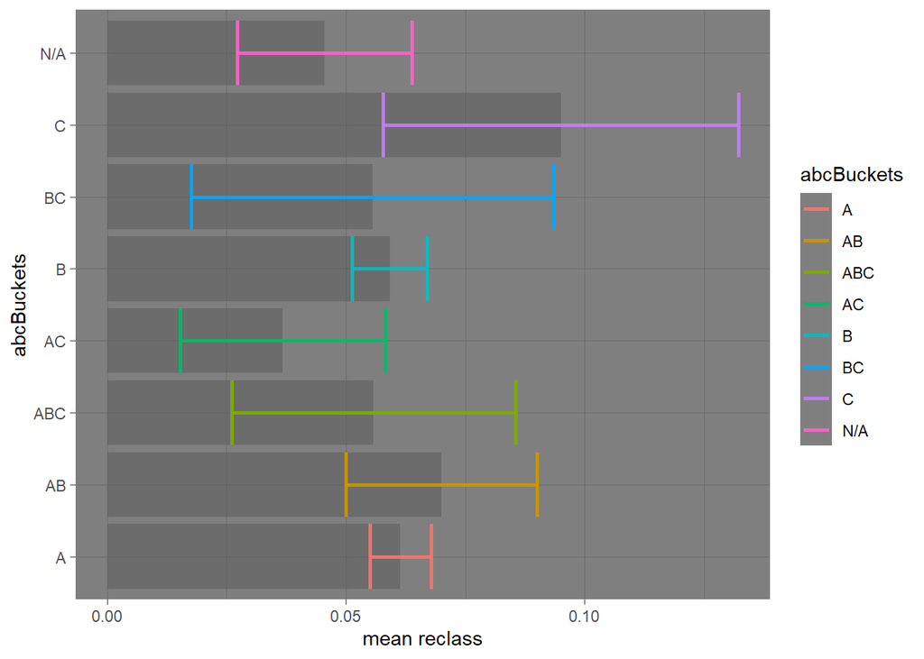

```r
reclassGG
```

## Analysis

In order to explore how REA impacts exome reporting, this study will build logistic and multinomial models using abc and default REA buckets as predictors to determine how an exome may be classified, whether an exome is reanalyzed or reclassified, how a reanalysis is initiated, and the evidence used to make a reclassification. Including sex, age, and indication as possible confounders.

To statistically evaluate the impact of REA on exome reporting, this study has deployed the likelihood ratio test. The likelihood ratio test, in summary, compares how well two models fit by using the ratio of their likelihoods. In this case there is some probability that a given exome will be evaluated in some fashion based on the age, sex, and indication of the patient based on the data. Calculating the probability of how an exome will be evaluated including the patient REA, the test, assuming a null hypothesis that REA has no effect on exome evaluation, compares the estimated probabilities. If the test statistic falls below the threshold the null hypothesis is rejected and REA is significant to exome evaluation.

- Models, where the null was rejected (p<=0.05), indicate that abcBuckets/defaults are significant and should be included
- Models, failing to reject the null (p>0.05), indicate that abcBuckets/defaults are not significant and the simple model is preferred. These are cases where we are not observing significant variation between REA factors.

Below is a comparison of the constructed models and their likelihood ratio test statistic. Models below the threshold reject the null hypothesis, indicating REA significance, the others fail to do so.

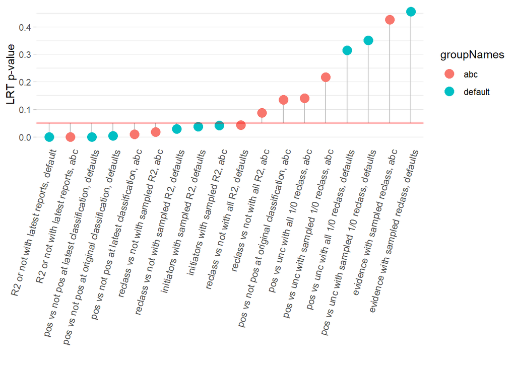

```r
descPlot
```

A table describing the models and listing their test statistic.

```r
plotFrame
```

```
## # A tibble: 18 × 5
##    names               LRTpv formula   desc                           groupNames
##    <chr>               <dbl> <list>    <chr>                          <chr>
##  1 lr.model2     0.000000113 <formula> R2 or not with latest reports… default
##  2 lr.model4     0.00000144  <formula> R2 or not with latest reports… abc
##  3 lr.model1.2   0.000167    <formula> pos vs not pos at latest clas… default
##  4 lr.model1.1   0.00446     <formula> pos vs not pos at original cl… default
##  5 lr.model3.2   0.0100      <formula> pos vs not pos at latest clas… abc
##  6 lr.reclass42  0.0179      <formula> reclass vs not with sampled R… abc
##  7 lr.reclass22  0.0297      <formula> reclass vs not with sampled R… default
##  8 lr.trigger7   0.0382      <chr [1]> initiators with sampled R2, d… default
##  9 lr.trigger9   0.0426      <chr [1]> initiators with sampled R2, a… default
## 10 lr.reclass21  0.0438      <formula> reclass vs not with all R2, d… abc
## 11 lr.reclass41  0.0880      <formula> reclass vs not with all R2, a… abc
## 12 lr.model3.1   0.136       <formula> pos vs not pos at original cl… abc
## 13 lr.outcomes51 0.141       <formula> pos vs unc with all 1/0 recla… abc
## 14 lr.outcomes52 0.218       <formula> pos vs unc with sampled 1/0 r… abc
## 15 lr.outcomes61 0.315       <formula> pos vs unc with all 1/0 recla… default
## 16 lr.outcomes62 0.351       <formula> pos vs unc with sampled 1/0 r… default
## 17 lr.evidence10 0.425       <chr [1]> evidence with sampled reclass… abc
## 18 lr.evidence8  0.455       <chr [1]> evidence with sampled reclass… default
```

### Model Details

For example:

```r
exMod <- glm(data = originals, formula = classification ~ abcBuckets, family = binomial)
summary(exMod)
```

```
##
## Call:
## glm(formula = classification ~ abcBuckets, family = binomial,
##     data = originals)
##
## Deviance Residuals:
##     Min       1Q   Median       3Q      Max
## -0.7549  -0.7328  -0.6673  -0.6494   1.9154
##
## Coefficients:
##               Estimate Std. Error z value Pr(>|z|)
## (Intercept)   -1.38886    0.03414 -40.683  < 2e-16 ***
## abcBucketsAB   0.16755    0.10110   1.657   0.0974 .
## abcBucketsABC  0.09139    0.16319   0.560   0.5754
## abcBucketsAC  -0.01425    0.14927  -0.095   0.9240
## abcBucketsB    0.21132    0.05247   4.028 5.63e-05 ***
## abcBucketsBC  -0.27144    0.23002  -1.180   0.2380
## abcBucketsC    0.27919    0.15273   1.828   0.0675 .
## abcBucketsN/A -0.06051    0.11844  -0.511   0.6094
## ---
## Signif. codes:  0 '***' 0.001 '**' 0.01 '*' 0.05 '.' 0.1 ' ' 1
##
## (Dispersion parameter for binomial family taken to be 1)
##
##     Null deviance: 11314  on 10920  degrees of freedom
## Residual deviance: 11291  on 10913  degrees of freedom
## AIC: 11307
##
## Number of Fisher Scoring iterations: 4
```

- (Intercept) here refers to the estimate about abcBucket A, forming the basis for the other estimates which each modify the intercept accordingly.
- Compare the estimates for abcBucket C and abcBucket B: although the estimate for C is larger than the estimate for B, it has a larger standard error resulting in a higher p-value and a lower significance. A low p-value indicates that the factor is likely non-zero and does explain the result, a high p-value means it is not possible to conclude the factor affects the output in this sample.

Likelihood Ratio Test example:

```r
exMod <- glm(data = originals, formula = classification ~ indication + abcBuckets, family = binomial)
exMod.red <- glm(data = originals, formula = classification ~ abcBuckets, family = binomial)

lrtest(exMod,exMod.red)
```

```
## Likelihood ratio test
##
## Model 1: classification ~ indication + abcBuckets
## Model 2: classification ~ abcBuckets
##   #Df  LogLik Df  Chisq Pr(>Chisq)
## 1   9 -5543.8
## 2   8 -5645.4 -1 203.21  < 2.2e-16 ***
## ---
## Signif. codes:  0 '***' 0.001 '**' 0.01 '*' 0.05 '.' 0.1 ' ' 1
```

This LRT is comparing a model including indication and REA, with the example model from above. The returned `Pr(>Chisq)`(p-value) indicated that the test null hypothesis, indication is not a meaningful predictor, should be rejected. In this example we prefer the updated model as it more accurately estimates an exome’s classification.

Example Binned Residual Plot

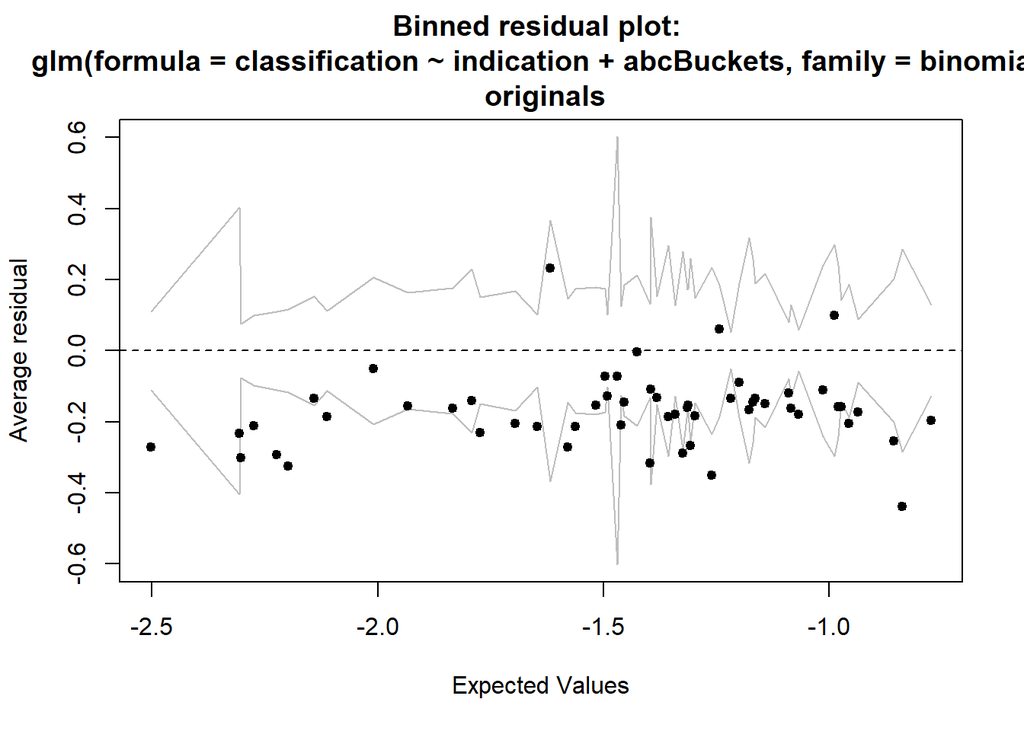

```r
binnResid(exMod)
```

A binned residual plot splits the data into bins, whereupon the average fitted value in each bin is compared with the bin’s average errors. As with most residual plots an adequate model fit should produce random, noisy residuals representative of normal sample noise: The reader should be mindful about interpreting models with residual plots that do not adhere to this chaotic standard. This could include patterns in residuals, extreme outliers or other orderly aberrations.

### Binary Models

#### pos vs not pos at original classification, defaults

```r
summary(model1.1)
```

```
##
## Call:
## glm(formula = classification ~ Default.REA.buckets + sex + age +
##     indication, family = binomial, data = originals)
##
## Deviance Residuals:
##     Min       1Q   Median       3Q      Max
## -1.0284  -0.7509  -0.6633  -0.4320   2.5082
##
## Coefficients:
##                                      Estimate Std. Error z value Pr(>|z|)
## (Intercept)                          -2.87460    0.15821 -18.170  < 2e-16 ***
## Default.REA.bucketsAshkenazi Jewish   0.17390    0.17357   1.002 0.316385
## Default.REA.bucketsAsian              0.48147    0.13419   3.588 0.000333 ***
## Default.REA.bucketsHispanic / Latino  0.26295    0.11024   2.385 0.017064 *
## Default.REA.bucketsMultiracial        0.17263    0.11803   1.463 0.143570
## Default.REA.bucketsN/A                0.05419    0.15052   0.360 0.718826
## Default.REA.bucketsOther              0.33269    0.18030   1.845 0.065016 .
## Default.REA.bucketsWhite              0.12875    0.10396   1.238 0.215547
## sexMale                              -0.17262    0.04766  -3.622 0.000293 ***
## age.L                                -0.88313    0.18408  -4.798 1.61e-06 ***
## age.Q                                -0.30242    0.17085  -1.770 0.076717 .
## age.C                                -0.20676    0.14985  -1.380 0.167647
## age^4                                 0.05951    0.13246   0.449 0.653260
## age^5                                 0.09918    0.10939   0.907 0.364572
## age^6                                 0.12685    0.08219   1.543 0.122728
## age^7                                 0.11383    0.06083   1.871 0.061329 .
## indication                            5.79555    0.48262  12.008  < 2e-16 ***
## ---
## Signif. codes:  0 '***' 0.001 '**' 0.01 '*' 0.05 '.' 0.1 ' ' 1
##
## (Dispersion parameter for binomial family taken to be 1)
##
##     Null deviance: 11314  on 10920  degrees of freedom
## Residual deviance: 11029  on 10904  degrees of freedom
## AIC: 11063
##
## Number of Fisher Scoring iterations: 4
```

```r
lr.model1.1
```

```
## Likelihood ratio test
##
## Model 1: classification ~ Default.REA.buckets + sex + age + indication
## Model 2: classification ~ sex + age + indication
##   #Df  LogLik Df  Chisq Pr(>Chisq)
## 1  17 -5514.4
## 2  10 -5524.6 -7 20.571    0.00446 **
## ---
## Signif. codes:  0 '***' 0.001 '**' 0.01 '*' 0.05 '.' 0.1 ' ' 1
```

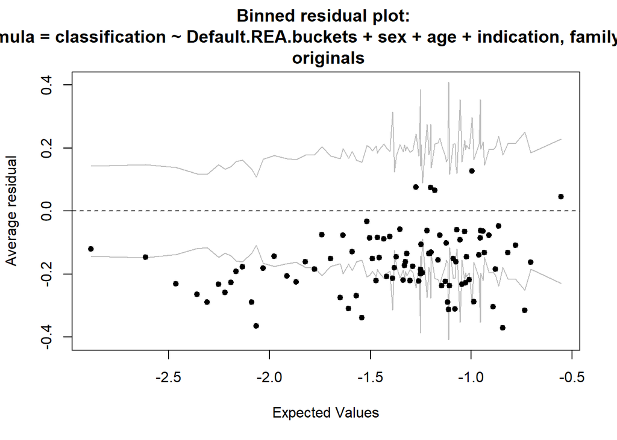

#### pos vs not pos at latest classification, defaults

```r
summary(model1.2)
```

```
##
## Call:
## glm(formula = classification ~ Default.REA.buckets + sex + age +
##     indication, family = binomial, data = latestAgiles)
##
## Deviance Residuals:
##     Min       1Q   Median       3Q      Max
## -1.3977  -1.0607  -0.8143   1.2634   1.8870
##
## Coefficients:
##                                      Estimate Std. Error z value Pr(>|z|)
## (Intercept)                          -1.88733    0.12350 -15.282  < 2e-16 ***
## Default.REA.bucketsAshkenazi Jewish  -0.05749    0.14208  -0.405 0.685722
## Default.REA.bucketsAsian              0.38707    0.11398   3.396 0.000684 ***
## Default.REA.bucketsHispanic / Latino  0.17521    0.09039   1.938 0.052573 .
## Default.REA.bucketsMultiracial        0.11458    0.09646   1.188 0.234853
## Default.REA.bucketsN/A               -0.02223    0.12218  -0.182 0.855617
## Default.REA.bucketsOther              0.45449    0.15301   2.970 0.002974 **
## Default.REA.bucketsWhite              0.06209    0.08421   0.737 0.460937
## sexMale                              -0.03354    0.04013  -0.836 0.403229
## age.L                                -0.15769    0.14881  -1.060 0.289283
## age.Q                                -0.34221    0.13992  -2.446 0.014458 *
## age.C                                 0.13067    0.12111   1.079 0.280623
## age^4                                -0.09891    0.10274  -0.963 0.335679
## age^5                                 0.09096    0.08346   1.090 0.275804
## age^6                                 0.02324    0.06445   0.361 0.718459
## age^7                                 0.03623    0.04979   0.728 0.466839
## indication                            5.61387    0.37169  15.104  < 2e-16 ***
## ---
## Signif. codes:  0 '***' 0.001 '**' 0.01 '*' 0.05 '.' 0.1 ' ' 1
##
## (Dispersion parameter for binomial family taken to be 1)
##
##     Null deviance: 14724  on 10920  degrees of freedom
## Residual deviance: 14379  on 10904  degrees of freedom
## AIC: 14413
##
## Number of Fisher Scoring iterations: 4
```

```r
lr.model1.2
```

```
## Likelihood ratio test
##
## Model 1: classification ~ Default.REA.buckets + sex + age + indication
## Model 2: classification ~ sex + age + indication
##   #Df  LogLik Df  Chisq Pr(>Chisq)
## 1  17 -7189.5
## 2  10 -7203.8 -7 28.664  0.0001666 ***
## ---
## Signif. codes:  0 '***' 0.001 '**' 0.01 '*' 0.05 '.' 0.1 ' ' 1
```

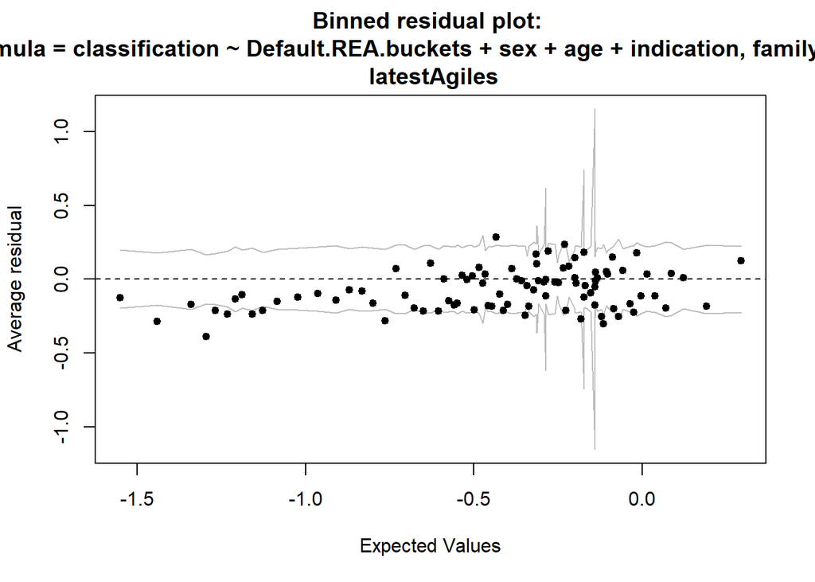

#### pos vs not pos at original classification, abc

```r
summary(model3.1)
```

```
##
## Call:
## glm(formula = classification ~ abcBuckets + sex + age + indication,
##     family = binomial, data = originals)
##
## Deviance Residuals:
##     Min       1Q   Median       3Q      Max
## -0.9904  -0.7509  -0.6693  -0.4343   2.5036
##
## Coefficients:
##                Estimate Std. Error z value Pr(>|z|)
## (Intercept)   -2.732517   0.126108 -21.668  < 2e-16 ***
## abcBucketsAB   0.102220   0.102418   0.998  0.31825
## abcBucketsABC  0.048777   0.165074   0.295  0.76762
## abcBucketsAC   0.007594   0.151301   0.050  0.95997
## abcBucketsB    0.122441   0.053542   2.287  0.02221 *
## abcBucketsBC  -0.342109   0.231813  -1.476  0.14000
## abcBucketsC    0.207857   0.154571   1.345  0.17871
## abcBucketsN/A -0.078060   0.119689  -0.652  0.51428
## sexMale       -0.173075   0.047643  -3.633  0.00028 ***
## age.L         -0.904897   0.183489  -4.932 8.15e-07 ***
## age.Q         -0.273994   0.169941  -1.612  0.10690
## age.C         -0.223310   0.149392  -1.495  0.13497
## age^4          0.074557   0.132280   0.564  0.57300
## age^5          0.094770   0.109298   0.867  0.38590
## age^6          0.132754   0.082140   1.616  0.10605
## age^7          0.113475   0.060815   1.866  0.06206 .
## indication     5.781127   0.482577  11.980  < 2e-16 ***
## ---
## Signif. codes:  0 '***' 0.001 '**' 0.01 '*' 0.05 '.' 0.1 ' ' 1
##
## (Dispersion parameter for binomial family taken to be 1)
##
##     Null deviance: 11314  on 10920  degrees of freedom
## Residual deviance: 11038  on 10904  degrees of freedom
## AIC: 11072
##
## Number of Fisher Scoring iterations: 4
```

```r
lr.model3.1
```

```
## Likelihood ratio test
##
## Model 1: classification ~ abcBuckets + sex + age + indication
## Model 2: classification ~ sex + age + indication
##   #Df  LogLik Df Chisq Pr(>Chisq)
## 1  17 -5519.1
## 2  10 -5524.6 -7 11.07     0.1356
```

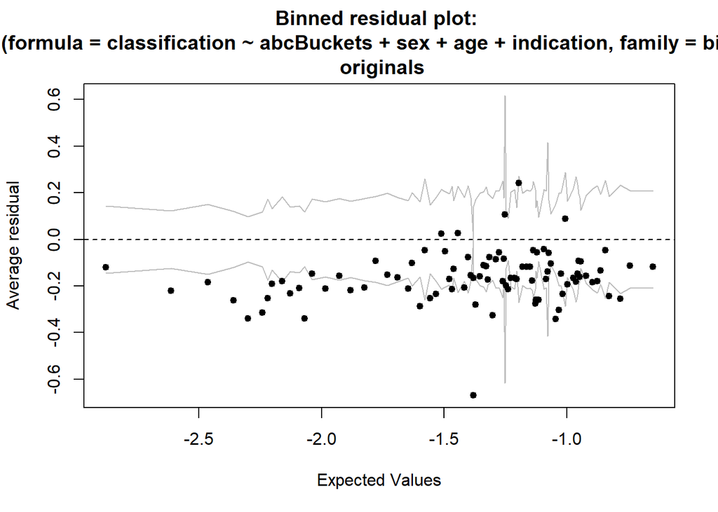

#### pos vs not pos at latest classification, abc

```r
summary(model3.2)
```

```
##
## Call:
## glm(formula = classification ~ abcBuckets + sex + age + indication,
##     family = binomial, data = latestAgiles)
##
## Deviance Residuals:
##     Min       1Q   Median       3Q      Max
## -1.3832  -1.0677  -0.8049   1.2647   1.8914
##
## Coefficients:
##               Estimate Std. Error z value Pr(>|z|)
## (Intercept)   -1.82645    0.09648 -18.931  < 2e-16 ***
## abcBucketsAB   0.14762    0.08673   1.702  0.08875 .
## abcBucketsABC  0.04700    0.13855   0.339  0.73441
## abcBucketsAC  -0.02556    0.12523  -0.204  0.83828
## abcBucketsB    0.12035    0.04531   2.656  0.00790 **
## abcBucketsBC  -0.12051    0.17732  -0.680  0.49674
## abcBucketsC    0.39359    0.13358   2.947  0.00321 **
## abcBucketsN/A -0.07714    0.09760  -0.790  0.42934
## sexMale       -0.03391    0.04011  -0.845  0.39794
## age.L         -0.18544    0.14828  -1.251  0.21108
## age.Q         -0.31874    0.13915  -2.291  0.02199 *
## age.C          0.11108    0.12070   0.920  0.35739
## age^4         -0.08738    0.10257  -0.852  0.39428
## age^5          0.08395    0.08336   1.007  0.31390
## age^6          0.02669    0.06440   0.414  0.67852
## age^7          0.03636    0.04978   0.731  0.46508
## indication     5.61144    0.37147  15.106  < 2e-16 ***
## ---
## Signif. codes:  0 '***' 0.001 '**' 0.01 '*' 0.05 '.' 0.1 ' ' 1
##
## (Dispersion parameter for binomial family taken to be 1)
##
##     Null deviance: 14724  on 10920  degrees of freedom
## Residual deviance: 14389  on 10904  degrees of freedom
## AIC: 14423
##
## Number of Fisher Scoring iterations: 4
```

```r
lr.model3.2
```

```
## Likelihood ratio test
##
## Model 1: classification ~ abcBuckets + sex + age + indication
## Model 2: classification ~ sex + age + indication
##   #Df  LogLik Df  Chisq Pr(>Chisq)
## 1  17 -7194.6
## 2  10 -7203.8 -7 18.476   0.009999 **
## ---
## Signif. codes:  0 '***' 0.001 '**' 0.01 '*' 0.05 '.' 0.1 ' ' 1
```

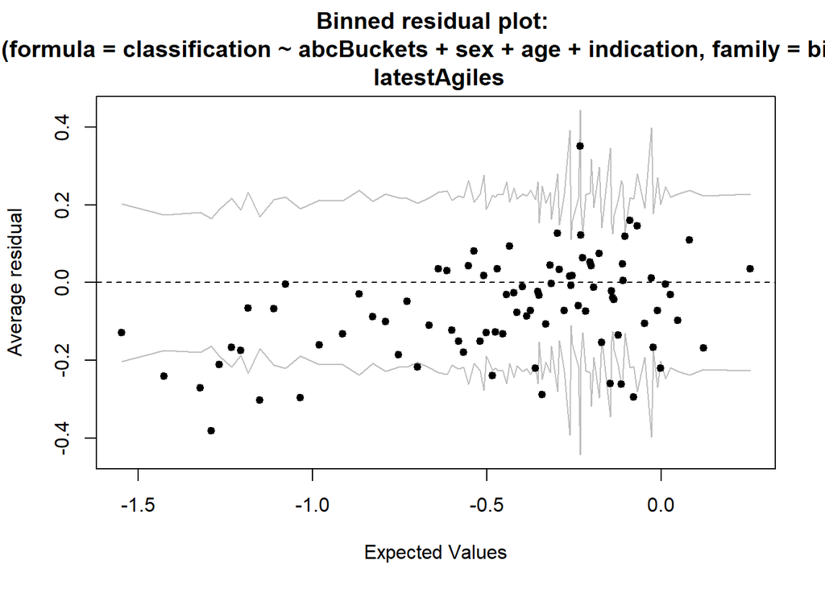

#### R2 or not with latest reports, default

```r
summary(model2)
```

```
##
## Call:
## glm(formula = reanalyzed ~ Default.REA.buckets + sex + age +
##     indication, family = binomial, data = latestAgiles)
##
## Deviance Residuals:
##     Min       1Q   Median       3Q      Max
## -0.7967  -0.6820  -0.5990  -0.4635   2.7914
##
## Coefficients:
##                                      Estimate Std. Error z value Pr(>|z|)
## (Intercept)                          -3.03652    0.17998 -16.871  < 2e-16 ***
## Default.REA.bucketsAshkenazi Jewish   0.44847    0.18776   2.389 0.016916 *
## Default.REA.bucketsAsian              0.36372    0.15702   2.316 0.020541 *
## Default.REA.bucketsHispanic / Latino  0.30705    0.12724   2.413 0.015813 *
## Default.REA.bucketsMultiracial        0.42887    0.13327   3.218 0.001290 **
## Default.REA.bucketsN/A               -0.04153    0.17883  -0.232 0.816379
## Default.REA.bucketsOther              0.47549    0.20027   2.374 0.017581 *
## Default.REA.bucketsWhite              0.55500    0.11916   4.658 3.20e-06 ***
## sexMale                              -0.02037    0.05097  -0.400 0.689402
## age.L                                 0.47665    0.34243   1.392 0.163935
## age.Q                                -1.25606    0.33545  -3.744 0.000181 ***
## age.C                                 1.18331    0.27593   4.288 1.80e-05 ***
## age^4                                -0.48541    0.20024  -2.424 0.015344 *
## age^5                                 0.09545    0.13735   0.695 0.487098
## age^6                                -0.33510    0.09667  -3.466 0.000528 ***
## age^7                                -0.08868    0.06816  -1.301 0.193269
## indication                            2.99593    0.47749   6.274 3.51e-10 ***
## ---
## Signif. codes:  0 '***' 0.001 '**' 0.01 '*' 0.05 '.' 0.1 ' ' 1
##
## (Dispersion parameter for binomial family taken to be 1)
##
##     Null deviance: 10260  on 10920  degrees of freedom
## Residual deviance: 10066  on 10904  degrees of freedom
## AIC: 10100
##
## Number of Fisher Scoring iterations: 5
```

```r
lr.model2
```

```
## Likelihood ratio test
##
## Model 1: reanalyzed ~ Default.REA.buckets + sex + age + indication
## Model 2: reanalyzed ~ sex + age + indication
##   #Df  LogLik Df  Chisq Pr(>Chisq)
## 1  17 -5032.8
## 2  10 -5055.5 -7 45.436  1.125e-07 ***
## ---
## Signif. codes:  0 '***' 0.001 '**' 0.01 '*' 0.05 '.' 0.1 ' ' 1
```

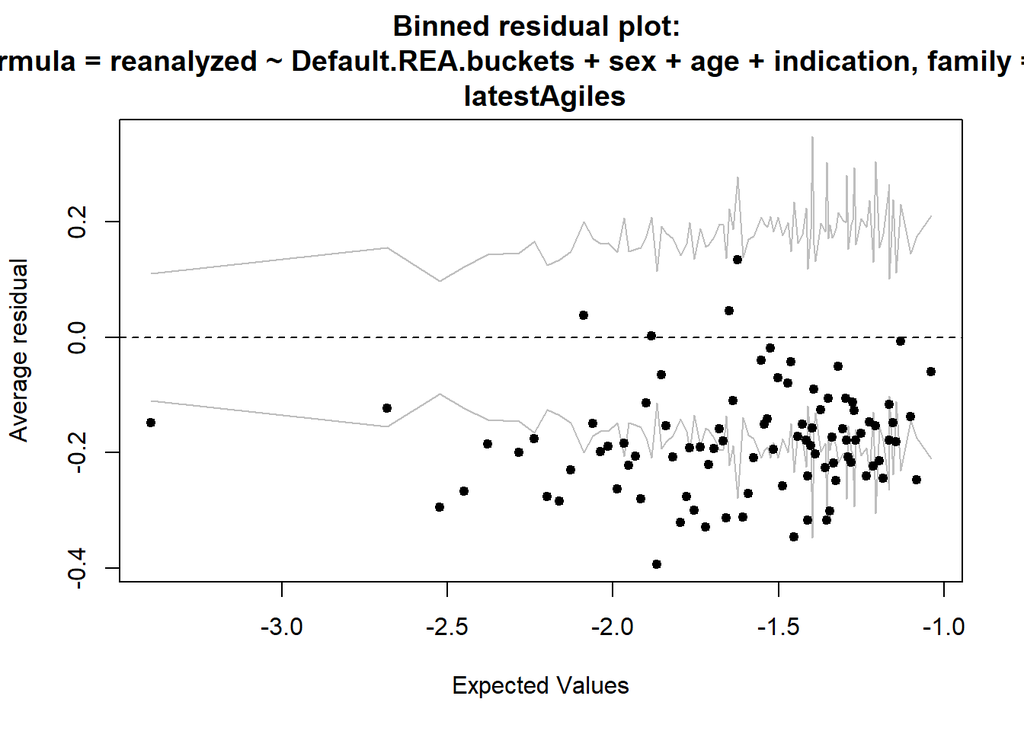

#### R2 or not with latest reports, abc

```r
summary(model4)
```

```
##
## Call:
## glm(formula = reanalyzed ~ abcBuckets + sex + age + indication,
##     family = binomial, data = latestAgiles)
##
## Deviance Residuals:
##     Min       1Q   Median       3Q      Max
## -0.8070  -0.6772  -0.6058  -0.4614   2.8214
##
## Coefficients:
##               Estimate Std. Error z value Pr(>|z|)
## (Intercept)   -2.49072    0.14044 -17.736  < 2e-16 ***
## abcBucketsAB  -0.11035    0.10881  -1.014 0.310524
## abcBucketsABC  0.07871    0.16337   0.482 0.629954
## abcBucketsAC  -0.22629    0.16247  -1.393 0.163669
## abcBucketsB   -0.28586    0.05825  -4.907 9.23e-07 ***
## abcBucketsBC  -0.20860    0.22396  -0.931 0.351626
## abcBucketsC   -0.08105    0.16865  -0.481 0.630810
## abcBucketsN/A -0.58947    0.14257  -4.135 3.55e-05 ***
## sexMale       -0.02110    0.05096  -0.414 0.678774
## age.L          0.46069    0.34219   1.346 0.178211
## age.Q         -1.25126    0.33513  -3.734 0.000189 ***
## age.C          1.17591    0.27577   4.264 2.01e-05 ***
## age^4         -0.47723    0.20018  -2.384 0.017127 *
## age^5          0.09561    0.13730   0.696 0.486191
## age^6         -0.33291    0.09664  -3.445 0.000572 ***
## age^7         -0.08822    0.06816  -1.294 0.195540
## indication     3.00907    0.47737   6.303 2.91e-10 ***
## ---
## Signif. codes:  0 '***' 0.001 '**' 0.01 '*' 0.05 '.' 0.1 ' ' 1
##
## (Dispersion parameter for binomial family taken to be 1)
##
##     Null deviance: 10260  on 10920  degrees of freedom
## Residual deviance: 10071  on 10904  degrees of freedom
## AIC: 10105
##
## Number of Fisher Scoring iterations: 5
```

```r
lr.model4
```

```
## Likelihood ratio test
##
## Model 1: reanalyzed ~ abcBuckets + sex + age + indication
## Model 2: reanalyzed ~ sex + age + indication
##   #Df  LogLik Df  Chisq Pr(>Chisq)
## 1  17 -5035.6
## 2  10 -5055.5 -7 39.692  1.442e-06 ***
## ---
## Signif. codes:  0 '***' 0.001 '**' 0.01 '*' 0.05 '.' 0.1 ' ' 1
```

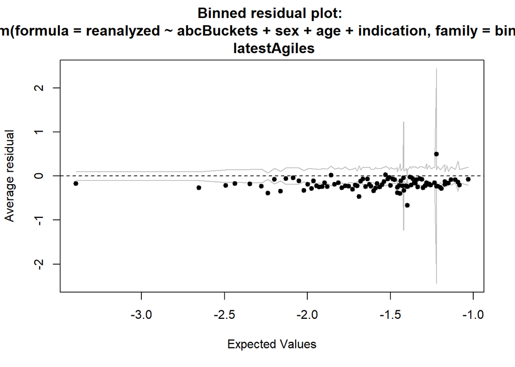

#### reclass vs not with sampled R2, defaults

```r
summary(reclass22)
```

```
##
## Call:
## glm(formula = Reclassified ~ Default.REA.buckets + age + sex +
##     indication, family = binomial, data = uniqueReanaz)
##
## Deviance Residuals:
##     Min       1Q   Median       3Q      Max
## -1.3605  -0.9364  -0.8573   1.3875   1.9998
##
## Coefficients:
##                                       Estimate Std. Error z value Pr(>|z|)
## (Intercept)                          -1.343320   0.340428  -3.946 7.95e-05 ***
## Default.REA.bucketsAshkenazi Jewish  -0.329343   0.344223  -0.957   0.3387
## Default.REA.bucketsAsian             -0.132639   0.285983  -0.464   0.6428
## Default.REA.bucketsHispanic / Latino -0.415417   0.233522  -1.779   0.0753 .
## Default.REA.bucketsMultiracial       -0.472984   0.244693  -1.933   0.0532 .
## Default.REA.bucketsN/A               -0.010875   0.327271  -0.033   0.9735
## Default.REA.bucketsOther              0.383423   0.351836   1.090   0.2758
## Default.REA.bucketsWhite             -0.443701   0.216631  -2.048   0.0405 *
## age.L                                 0.598956   0.646659   0.926   0.3543
## age.Q                                -0.630338   0.630567  -1.000   0.3175
## age.C                                 0.518578   0.521005   0.995   0.3196
## age^4                                 0.031579   0.386145   0.082   0.9348
## age^5                                 0.629574   0.270360   2.329   0.0199 *
## age^6                                 0.250244   0.189036   1.324   0.1856
## age^7                                 0.099801   0.128794   0.775   0.4384
## sexMale                               0.007663   0.094111   0.081   0.9351
## indication                            3.961802   0.962090   4.118 3.82e-05 ***
## ---
## Signif. codes:  0 '***' 0.001 '**' 0.01 '*' 0.05 '.' 0.1 ' ' 1
##
## (Dispersion parameter for binomial family taken to be 1)
##
##     Null deviance: 2692.4  on 2075  degrees of freedom
## Residual deviance: 2651.7  on 2059  degrees of freedom
## AIC: 2685.7
##
## Number of Fisher Scoring iterations: 4
```

```r
lr.reclass22
```

```
## Likelihood ratio test
##
## Model 1: Reclassified ~ Default.REA.buckets + age + sex + indication
## Model 2: Reclassified ~ age + sex + indication
##   #Df  LogLik Df  Chisq Pr(>Chisq)
## 1  17 -1325.8
## 2  10 -1333.6 -7 15.534    0.02973 *
## ---
## Signif. codes:  0 '***' 0.001 '**' 0.01 '*' 0.05 '.' 0.1 ' ' 1
```

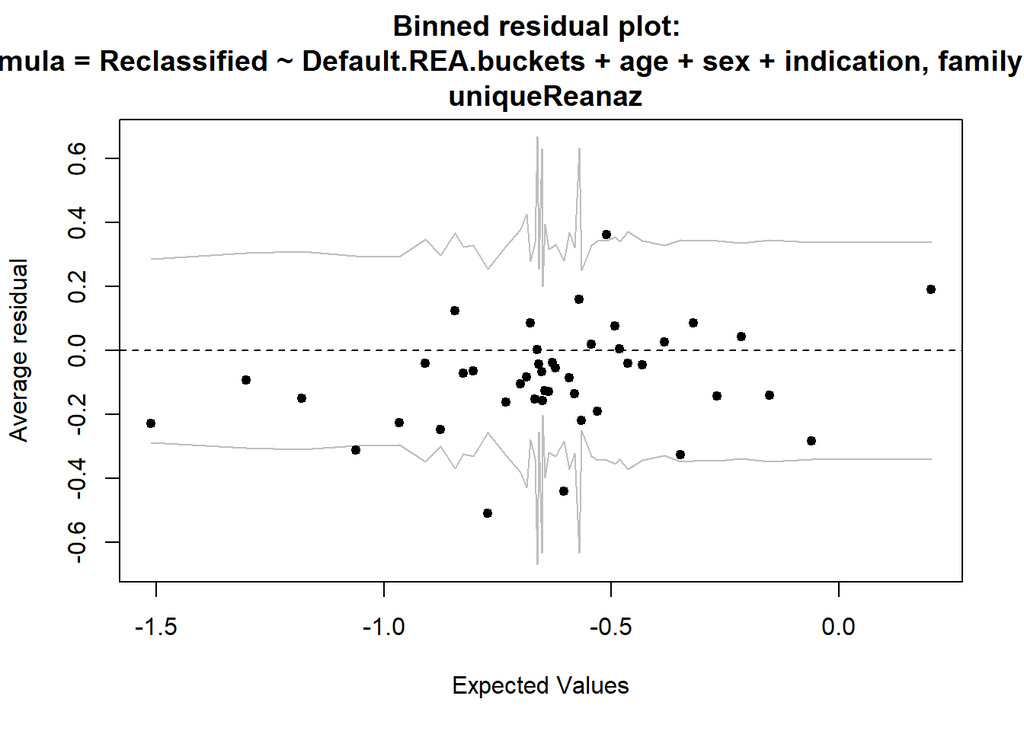

#### reclass vs not with sampled R2, abc

```r
summary(reclass42)
```

```
##
## Call:
## glm(formula = Reclassified ~ abcBuckets + age + sex + indication,
##     family = binomial, data = uniqueReanaz)
##
## Deviance Residuals:
##     Min       1Q   Median       3Q      Max
## -1.3795  -0.9569  -0.8553   1.3738   2.0266
##
## Coefficients:
##                Estimate Std. Error z value Pr(>|z|)
## (Intercept)   -1.703595   0.279041  -6.105 1.03e-09 ***
## abcBucketsAB   0.201806   0.196396   1.028  0.30416
## abcBucketsABC -0.304806   0.321009  -0.950  0.34235
## abcBucketsAC  -0.566145   0.350109  -1.617  0.10587
## abcBucketsB    0.139178   0.107219   1.298  0.19426
## abcBucketsBC   0.334095   0.399832   0.836  0.40339
## abcBucketsC    0.825324   0.292216   2.824  0.00474 **
## abcBucketsN/A  0.429397   0.262406   1.636  0.10176
## age.L          0.598931   0.643338   0.931  0.35187
## age.Q         -0.563746   0.628075  -0.898  0.36941
## age.C          0.470755   0.519571   0.906  0.36491
## age^4          0.026560   0.385141   0.069  0.94502
## age^5          0.617215   0.270257   2.284  0.02238 *
## age^6          0.267643   0.189033   1.416  0.15682
## age^7          0.111384   0.128877   0.864  0.38744
## sexMale        0.009735   0.094162   0.103  0.91766
## indication     3.728983   0.956810   3.897 9.73e-05 ***
## ---
## Signif. codes:  0 '***' 0.001 '**' 0.01 '*' 0.05 '.' 0.1 ' ' 1
##
## (Dispersion parameter for binomial family taken to be 1)
##
##     Null deviance: 2692.4  on 2075  degrees of freedom
## Residual deviance: 2650.3  on 2059  degrees of freedom
## AIC: 2684.3
##
## Number of Fisher Scoring iterations: 4
```

```r
lr.reclass42
```

```
## Likelihood ratio test
##
## Model 1: Reclassified ~ abcBuckets + age + sex + indication
## Model 2: Reclassified ~ age + sex + indication
##   #Df  LogLik Df Chisq Pr(>Chisq)
## 1  17 -1325.2
## 2  10 -1333.6 -7 16.92    0.01792 *
## ---
## Signif. codes:  0 '***' 0.001 '**' 0.01 '*' 0.05 '.' 0.1 ' ' 1
```

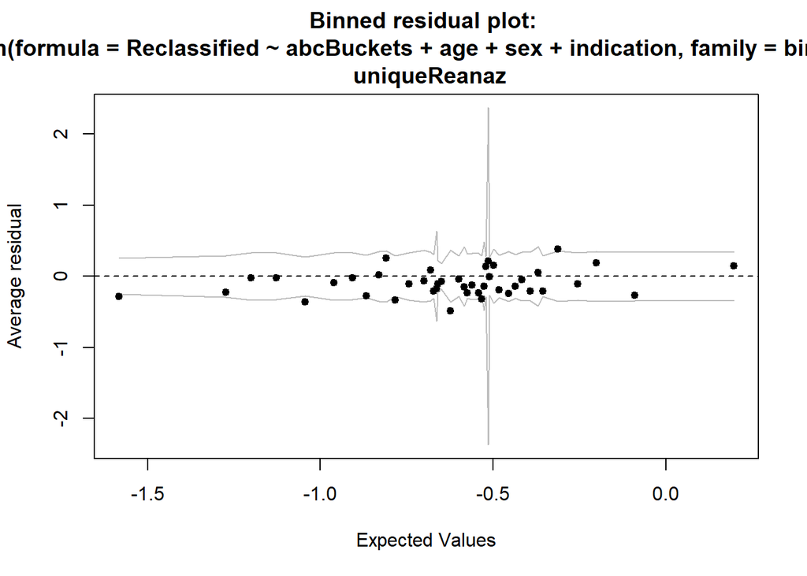

#### pos vs unc with sampled 1/0 reclass, abc

```r
summary(outcomes52)
```

```
##
## Call:
## glm(formula = classification ~ abcBuckets + age + sex + indication,
##     family = binomial, data = uniqueUncertain)
##
## Deviance Residuals:
##     Min       1Q   Median       3Q      Max
## -1.6768  -1.2790   0.9151   1.0271   1.5428
##
## Coefficients:
##                Estimate Std. Error z value Pr(>|z|)
## (Intercept)   -0.063912   0.442730  -0.144   0.8852
## abcBucketsAB  -0.000657   0.321843  -0.002   0.9984
## abcBucketsABC -0.559266   0.548596  -1.019   0.3080
## abcBucketsAC   0.384743   0.614549   0.626   0.5313
## abcBucketsB   -0.406924   0.177453  -2.293   0.0218 *
## abcBucketsBC  -0.727816   0.684136  -1.064   0.2874
## abcBucketsC    0.431012   0.464219   0.928   0.3532
## abcBucketsN/A  0.076881   0.422376   0.182   0.8556
## age.L         -0.702744   0.461160  -1.524   0.1275
## age.Q         -0.355844   0.405983  -0.877   0.3808
## age.C          0.062900   0.404723   0.155   0.8765
## age^4         -0.090474   0.385473  -0.235   0.8144
## age^5         -0.049044   0.345324  -0.142   0.8871
## age^6          0.056455   0.255991   0.221   0.8255
## sexMale        0.130880   0.156706   0.835   0.4036
## indication     1.020368   1.683810   0.606   0.5445
## ---
## Signif. codes:  0 '***' 0.001 '**' 0.01 '*' 0.05 '.' 0.1 ' ' 1
##
## (Dispersion parameter for binomial family taken to be 1)
##
##     Null deviance: 953.63  on 702  degrees of freedom
## Residual deviance: 939.93  on 687  degrees of freedom
## AIC: 971.93
##
## Number of Fisher Scoring iterations: 4
```

```r
lr.outcomes52
```

```
## Likelihood ratio test
##
## Model 1: classification ~ abcBuckets + age + sex + indication
## Model 2: classification ~ age + sex + indication
##   #Df  LogLik Df Chisq Pr(>Chisq)
## 1  16 -469.97
## 2   9 -474.72 -7 9.513     0.2179
```

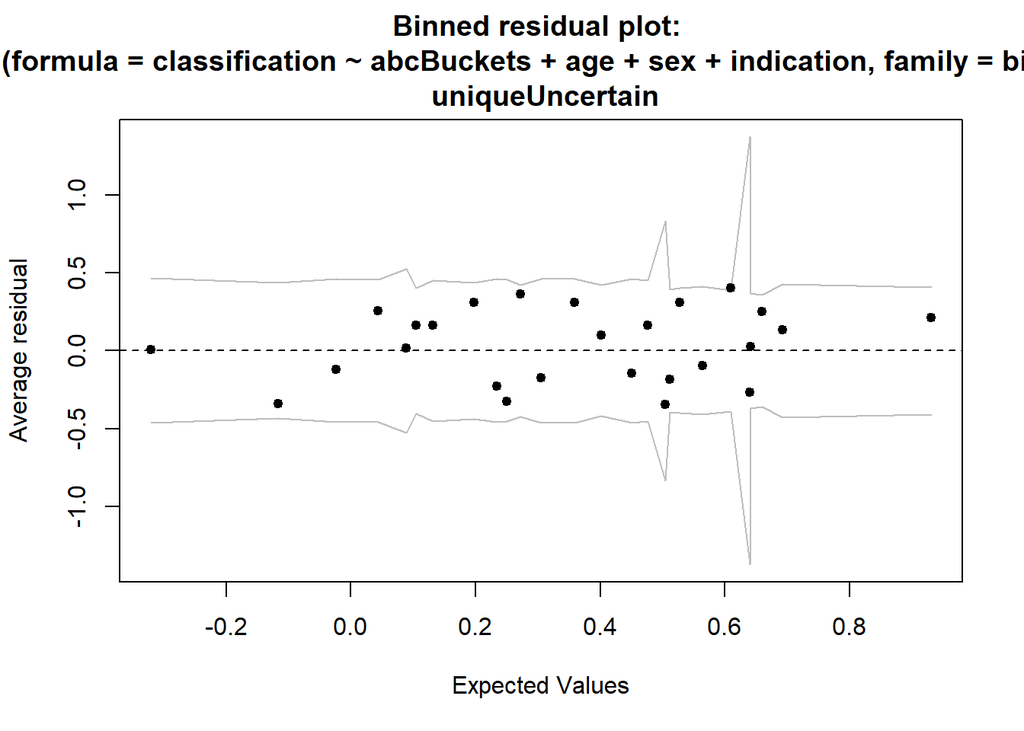

#### pos vs unc with sampled 1/0 reclass, defaults

```r
summary(outcomes62)
```

```
##
## Call:
## glm(formula = classification ~ Default.REA.buckets + age + sex +
##     indication, family = binomial, data = uniqueUncertain)
##
## Deviance Residuals:
##     Min       1Q   Median       3Q      Max
## -1.6774  -1.2842   0.9263   1.0333   1.5914
##
## Coefficients:
##                                      Estimate Std. Error z value Pr(>|z|)
## (Intercept)                          -0.54061    0.53046  -1.019    0.308
## Default.REA.bucketsAshkenazi Jewish   0.85682    0.59609   1.437    0.151
## Default.REA.bucketsAsian              0.22922    0.45005   0.509    0.611
## Default.REA.bucketsHispanic / Latino  0.02843    0.36720   0.077    0.938
## Default.REA.bucketsMultiracial        0.29016    0.38841   0.747    0.455
## Default.REA.bucketsN/A                0.52726    0.51898   1.016    0.310
## Default.REA.bucketsOther              0.88201    0.55337   1.594    0.111
## Default.REA.bucketsWhite              0.43382    0.33820   1.283    0.200
## age.L                                -0.72815    0.46425  -1.568    0.117
## age.Q                                -0.41962    0.41049  -1.022    0.307
## age.C                                 0.02378    0.40777   0.058    0.953
## age^4                                -0.09249    0.38657  -0.239    0.811
## age^5                                -0.04835    0.34587  -0.140    0.889
## age^6                                 0.06502    0.25572   0.254    0.799
## sexMale                               0.10921    0.15650   0.698    0.485
## indication                            1.13880    1.70715   0.667    0.505
##
## (Dispersion parameter for binomial family taken to be 1)
##
##     Null deviance: 953.63  on 702  degrees of freedom
## Residual deviance: 941.65  on 687  degrees of freedom
## AIC: 973.65
##
## Number of Fisher Scoring iterations: 4
```

```r
lr.outcomes62
```

```
## Likelihood ratio test
##
## Model 1: classification ~ Default.REA.buckets + age + sex + indication
## Model 2: classification ~ age + sex + indication
##   #Df  LogLik Df  Chisq Pr(>Chisq)
## 1  16 -470.83
## 2   9 -474.72 -7 7.7966     0.3509
```

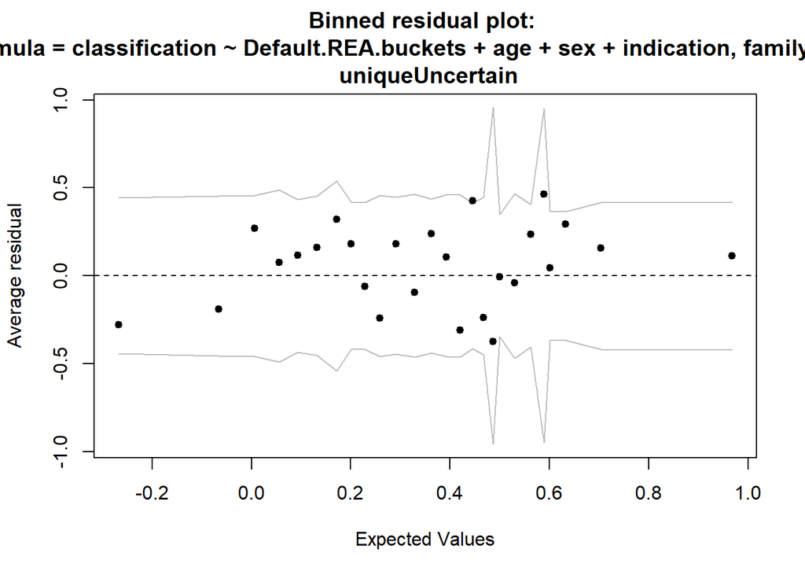

### Multinomial Models about Evidence and Initiators

#### initiators with sampled R2, defaults

```r
summary(trigger7)
```

```
## Call:
## multinom(formula = Initiator.of.reanalysis ~ Default.REA.buckets +
##     age + sex + indication, data = uniqueReanaz)
##
## Coefficients:
##                (Intercept) Default.REA.bucketsAshkenazi Jewish
## Family studies   -5.603949                          0.18847602
## Provider          2.096084                          0.06906129
##                Default.REA.bucketsAsian Default.REA.bucketsHispanic / Latino
## Family studies               0.41799791                            0.2637156
## Provider                    -0.02329149                            0.3800270
##                Default.REA.bucketsMultiracial Default.REA.bucketsN/A
## Family studies                     -0.7916958               1.615265
## Provider                            0.3287603               0.225119
##                Default.REA.bucketsOther Default.REA.bucketsWhite      age.L
## Family studies                0.5228756                0.2033775  7.7078138
## Provider                     -0.3369191                0.3336332 -0.2941156
##                      age.Q       age.C       age^4      age^5      age^6
## Family studies -13.3413595 13.61032321 -0.59680903  9.5901619  2.3292492
## Provider         0.6174401 -0.02018279 -0.02100764 -0.5735009 -0.2489634
##                       age^7     sexMale indication
## Family studies  2.412029668  0.01378832  -4.130328
## Provider       -0.008134707 -0.05937923  -4.740821
##
## Std. Errors:
##                (Intercept) Default.REA.bucketsAshkenazi Jewish
## Family studies   0.8522710                           0.9741961
## Provider         0.3828143                           0.3764000
##                Default.REA.bucketsAsian Default.REA.bucketsHispanic / Latino
## Family studies                0.7784580                            0.6918897
## Provider                      0.3144376                            0.2591930
##                Default.REA.bucketsMultiracial Default.REA.bucketsN/A
## Family studies                      0.8495713              0.7665450
## Provider                            0.2702817              0.3792438
##                Default.REA.bucketsOther Default.REA.bucketsWhite     age.L
## Family studies                0.8760037                0.6404860 0.5948621
## Provider                      0.3780692                0.2394969 0.6654993
##                    age.Q     age.C     age^4    age^5     age^6     age^7
## Family studies 0.7070326 0.4641302 0.3707996 0.272116 0.3289461 0.3174202
## Provider       0.6456890 0.5366162 0.4064002 0.292147 0.2067747 0.1416733
##                  sexMale indication
## Family studies 0.2717292   2.659962
## Provider       0.1056163   1.119681
##
## Residual Deviance: 2769.251
## AIC: 2837.251
```

```r
lr.trigger7
```

```
## Likelihood ratio test
##
## Model 1: Initiator.of.reanalysis ~ Default.REA.buckets + age + sex + indication
## Model 2: Initiator.of.reanalysis ~ age + sex + indication
##   #Df  LogLik  Df  Chisq Pr(>Chisq)
## 1  34 -1384.6
## 2  20 -1397.0 -14 24.644    0.03824 *
## ---
## Signif. codes:  0 '***' 0.001 '**' 0.01 '*' 0.05 '.' 0.1 ' ' 1
```

#### initiators with sampled R2, abc

```r
summary(trigger9)
```

```
## Call:
## multinom(formula = Initiator.of.reanalysis ~ abcBuckets + age +
##     sex + indication, data = uniqueReanaz)
##
## Coefficients:
##                (Intercept) abcBucketsAB abcBucketsABC abcBucketsAC abcBucketsB
## Family studies   -4.597822   -0.3053683   -13.0204082  -13.4007477  0.04120766
## Provider          2.323095   -0.1009157     0.1572908    0.2367142 -0.08331448
##                abcBucketsBC abcBucketsC abcBucketsN/A     age.L      age.Q
## Family studies  -21.2166484   0.3235836    1.41840797  4.079075 -9.8137428
## Provider         -0.1145614  -0.6603087   -0.09699808 -0.275457  0.5165223
##                      age.C       age^4      age^5      age^6       age^7
## Family studies 10.82524870  1.36342318  8.7030068  2.8098670  2.32393418
## Provider        0.02689523 -0.03305111 -0.5577197 -0.2628339 -0.01619102
##                    sexMale indication
## Family studies  0.02365414  -4.200039
## Provider       -0.06248301  -4.469902
##
## Std. Errors:
##                (Intercept) abcBucketsAB abcBucketsABC abcBucketsAC abcBucketsB
## Family studies   0.6460618    0.6363610  2.991109e-07 1.916080e-07   0.3108042
## Provider         0.3156401    0.2201301  3.497054e-01 3.648476e-01   0.1201411
##                abcBucketsBC abcBucketsC abcBucketsN/A     age.L     age.Q
## Family studies 6.975713e-11   0.6558461     0.5007781 0.5901023 0.6996794
## Provider       4.490920e-01   0.3104421     0.3120842 0.6616608 0.6428608
##                    age.C     age^4     age^5     age^6     age^7   sexMale
## Family studies 0.4585682 0.3681401 0.2651751 0.3278487 0.3172133 0.2716685
## Provider       0.5350713 0.4052172 0.2918854 0.2065698 0.1415777 0.1055511
##                indication
## Family studies   2.643807
## Provider         1.111344
##
## Residual Deviance: 2769.633
## AIC: 2837.633
```

```r
lr.trigger9
```

```
## Likelihood ratio test
##
## Model 1: Initiator.of.reanalysis ~ abcBuckets + age + sex + indication
## Model 2: Initiator.of.reanalysis ~ age + sex + indication
##   #Df  LogLik  Df  Chisq Pr(>Chisq)
## 1  34 -1384.8
## 2  20 -1397.0 -14 24.263    0.04258 *
## ---
## Signif. codes:  0 '***' 0.001 '**' 0.01 '*' 0.05 '.' 0.1 ' ' 1
```

#### evidence with sampled reclass, defaults

```r
summary(evidence8)
```

```
## Call:
## multinom(formula = Evidence.for.reclassification ~ Default.REA.buckets +
##     age + sex + indication, data = uniqueReclass)
##
## Coefficients:
##         (Intercept) Default.REA.bucketsAshkenazi Jewish
## Gene       4.174309                          -0.8244050
## Variant    1.912513                          -0.1544247
##         Default.REA.bucketsAsian Default.REA.bucketsHispanic / Latino
## Gene                   0.5451237                           -0.6104507
## Variant                0.8271394                           -0.5202287
##         Default.REA.bucketsMultiracial Default.REA.bucketsN/A
## Gene                         0.4951849             0.08345195
## Variant                      0.8543695             0.63486851
##         Default.REA.bucketsOther Default.REA.bucketsWhite     age.L      age.Q
## Gene                   -1.273023               -0.8836844 -2.700053  0.9077224
## Variant                -1.024440               -0.7378043  5.447127 -6.8681203
##              age.C     age^4    age^5    age^6    age^7   sexMale indication
## Gene    -10.936451  1.303153 3.634272 8.409183 4.744429 0.4860116   4.759810
## Variant  -4.310083 -2.577337 6.653773 8.113960 5.196967 0.7840167   2.305167
##
## Std. Errors:
##         (Intercept) Default.REA.bucketsAshkenazi Jewish
## Gene       0.959652                            1.086420
## Variant    1.007286                            1.110461
##         Default.REA.bucketsAsian Default.REA.bucketsHispanic / Latino
## Gene                    1.261902                            0.8214700
## Variant                 1.289509                            0.8574585
##         Default.REA.bucketsMultiracial Default.REA.bucketsN/A
## Gene                          1.033740               1.284759
## Variant                       1.061252               1.314378
##         Default.REA.bucketsOther Default.REA.bucketsWhite     age.L     age.Q
## Gene                   0.9793244                0.7615837 0.5035160 0.5012849
## Variant                1.0361389                0.7934783 0.5519819 0.5193492
##             age.C     age^4     age^5     age^6     age^7   sexMale indication
## Gene    0.4809792 0.5454363 0.4906060 0.3236239 0.3379835 0.2974924   2.880305
## Variant 0.5447316 0.6339397 0.5822411 0.3678695 0.3576038 0.3128412   3.025828
##
## Residual Deviance: 1280.258
## AIC: 1348.258
```

```r
lr.evidence8
```

```
## Likelihood ratio test
##
## Model 1: Evidence.for.reclassification ~ Default.REA.buckets + age + sex +
##     indication
## Model 2: Evidence.for.reclassification ~ age + sex + indication
##   #Df  LogLik  Df  Chisq Pr(>Chisq)
## 1  34 -640.13
## 2  20 -647.10 -14 13.936     0.4545
```

#### evidence with sampled reclass, abc

```r
summary(evidence10)
```

```
## Call:
## multinom(formula = Evidence.for.reclassification ~ abcBuckets +
##     age + sex + indication, data = uniqueReclass)
##
## Coefficients:
##         (Intercept) abcBucketsAB abcBucketsABC abcBucketsAC abcBucketsB
## Gene       3.825756     1.516077     0.3077706     13.37205   0.5643851
## Variant    1.692831     1.712122     0.1065914     13.66112   0.4826496
##         abcBucketsBC abcBucketsC abcBucketsN/A     age.L     age.Q      age.C
## Gene        12.32411  -0.3771501     0.9559785 -2.910437  1.178444 -12.354794
## Variant     13.20120  -0.3020247     1.3342777  5.736490 -7.000349  -5.318648
##             age^4    age^5    age^6    age^7   sexMale indication
## Gene     1.393700 4.184778 9.638036 5.463165 0.5186268   4.233409
## Variant -2.704414 7.333946 9.313630 5.931393 0.8203099   1.558626
##
## Std. Errors:
##         (Intercept) abcBucketsAB abcBucketsABC abcBucketsAC abcBucketsB
## Gene      0.6834064     1.037519      1.071310    0.2745467   0.3549324
## Variant   0.7203925     1.050707      1.142936    0.2745467   0.3725272
##         abcBucketsBC abcBucketsC abcBucketsN/A     age.L     age.Q     age.C
## Gene       0.3112826   0.6638325      1.062371 0.4956931 0.4916330 0.4699547
## Variant    0.3112826   0.7181894      1.078956 0.5420169 0.5062684 0.5325895
##             age^4     age^5     age^6     age^7   sexMale indication
## Gene    0.5393896 0.4855158 0.3108442 0.3350205 0.2968439   2.853185
## Variant 0.6265897 0.5767746 0.3557769 0.3549824 0.3123148   2.989675
##
## Residual Deviance: 1279.863
## AIC: 1347.863
```

```r
lr.evidence10
```

```
## Likelihood ratio test
##
## Model 1: Evidence.for.reclassification ~ abcBuckets + age + sex + indication
## Model 2: Evidence.for.reclassification ~ age + sex + indication
##   #Df  LogLik  Df  Chisq Pr(>Chisq)
## 1  34 -639.93
## 2  20 -647.10 -14 14.332     0.4253
```

### Notes

Additional analysis might consider the interaction between indication and REA, some testing showed REA significance increase when indication was interacted with. The author is working out how to generate binned residual plots about multinomial models. Those will be available for consideration in the final report.